# Innerdance — Design of Experiment for Autonomic Regulation

## A Practitioner's Guide: Modelling the Patient's Nervous System Response to Sound

**Purpose:** This notebook teaches innerdance facilitators how to run structured sound experiments that learn as much as possible about a patient's autonomic nervous system (ANS) with as few sessions as possible. It applies Design of Experiment (DoE) — an engineering discipline for learning efficiently — to clinical sound practice.

**What you will build, step by step:**

| Phase | Session | Goal | Model |
| --- | --- | --- | --- |
| **0 — Baseline** | Session 1, first 5 min | Where is this person's ANS right now? | Personal anchor values |
| **1 — Screening** | Session 1, ~40 min | Which 2–3 sound factors move the needle? | Simple linear |
| **2 — Mapping** | Session 2 | How do the top factors interact? Draw the map. | Quadratic surface |
| **3 — Optimise** | Session 3+ | Find settings that work even on bad days (resilience) | Robust optimisation |
| **Ongoing** | Weekly | Adapt as the patient improves | Adaptive sampling |

**How to use this notebook:**

1. `Kernel → Restart & Run All` on first use
2. Set `DEMO_MODE = False` and fill `PATIENT_FILE` when you have real Polar H10 data
3. Follow **🔬 Protocol** boxes for what to do in the room
4. Follow **⚠️ Medical Flag** boxes — these require clinical review

> **This is a personalised model.** Each patient gets their own copy. Reactions to sound are individual.

## ⚠️ MEDICAL SAFETY FRAMEWORK — Read Before Every Session

> **All content in this box requires independent review by a qualified clinician before use on real patients.**

### Absolute contraindications — DO NOT proceed without medical clearance

| Condition | Risk | Why |
| --- | --- | --- |
| Active epilepsy / seizure disorder | ❌ STOP | Rhythmic audio stimulation can trigger seizures |
| Implanted cardiac device (pacemaker, ICD) | ❌ STOP | Sub-bass frequencies (20–80 Hz) may interfere with sensing |
| Uncontrolled cardiac arrhythmia (AF, VT) | ❌ STOP | Autonomic stimulation may worsen dysrhythmia |
| Hypertensive crisis (SBP > 180 mmHg) | ❌ STOP | SNS activation contraindicated |
| Active psychosis or acute mania | ❌ STOP | Altered sensory processing; unpredictable response |
| Ménière's disease / active vestibular disorder | ❌ STOP | Sub-bass via bone conduction worsens symptoms |
| Pregnancy (sub-bass-heavy stages) | ❌ STOP | Vibrotactile safety not established in pregnancy |

### Relative contraindications — proceed with enhanced monitoring

| Condition | Precaution |
| --- | --- |
| Controlled hypertension | Avoid Stage 4-equivalent stimuli until map is built. Monitor HR throughout. |
| Beta-blockers (metoprolol, atenolol, etc.) | These **blunt HRV**. SD2 and DFA α1 baselines will be lower. Flag in model. |
| SSRIs / SNRIs | Alter ANS tone. May reduce HF-HRV. Flag in model. |
| Type 1 diabetes | ANS symptoms can mask hypoglycaemia. Check blood glucose before session. |
| PTSD | Only with a trauma-trained clinician present. Do not use activating stages solo. |
| Severe anxiety disorder | Begin with Phase 2 mapping only — no Phase 3 disturbance loading until resilience is confirmed. |

### Required monitoring during every session

- Polar H10 worn throughout. Live HR visible to facilitator.
- **Self-report check after every window:** ask distress level (0–10)
- **HR upper limit:** if HR > 85 % of HRmax (estimated: 220 − age) → shift immediately to recovery sound
- **HR lower limit:** if HR < 40 bpm → shift immediately to recovery sound, call medical support
- **SD2 alarm (in model):** if SD2 < 25 ms sustained > 2 min → shift to recovery sound

### Stop immediately if any of the following occur

- Chest pain or palpitations reported
- Dizziness, near-syncope, or visual disturbance
- Hyperventilation not resolving within 60 seconds
- Dissociation or psychological flooding
- Patient requests to stop — no exceptions

### Volume safety

- Keep all stages ≤ 85 dB SPL for sessions > 2 hours (NIOSH / WHO guideline)
- Use calibrated speaker or in-ear SPL meter if available

```python
import sys, warnings
sys.path.insert(0, '..')
warnings.filterwarnings('ignore')

import numpy as np
import pandas as pd
import matplotlib.pyplot as plt
import matplotlib.gridspec as gridspec
from matplotlib import cm
from mpl_toolkits.mplot3d import Axes3D
from scipy import stats
from sklearn.preprocessing import PolynomialFeatures
from sklearn.linear_model import LinearRegression
from sklearn.gaussian_process import GaussianProcessRegressor
from sklearn.gaussian_process.kernels import ConstantKernel, RBF, WhiteKernel
from sklearn.metrics import r2_score, mean_squared_error

# ── Load from existing pipeline libraries ─────────────────────────────────────
from processing.hrv_core import (
    load_rr_polar_ecg, preprocess_rr,
    metrics_in_window, sdnn as compute_sdnn,
)
from processing.acoustic_core import categorize

# ── Global config ─────────────────────────────────────────────────────────────
DEMO_MODE    = True           # ← set False when you have real patient data
PATIENT_ID   = 'P_demo'
PATIENT_AGE  = 35             # ← update per patient (used for HR safety limit)
PATIENT_FILE = None           # ← e.g. '../data/P01_session01.csv'

BG  = '#0d0d1a'
FG  = '#e0e0e0'
ACC = '#76b7b2'

HR_MAX = 220 - PATIENT_AGE
HR_SAFE_UPPER = 0.85 * HR_MAX
print(f'Patient: {PATIENT_ID}  |  Age: {PATIENT_AGE}  |  HR safety ceiling: {HR_SAFE_UPPER:.0f} bpm')
print('✅ Libraries loaded')
```

```
Patient: P_demo  |  Age: 35  |  HR safety ceiling: 157 bpm
✅ Libraries loaded
```

## The Science in 5 Minutes

### The Autonomic Nervous System (ANS)

Your body's survival system has two branches that work as a team:

| Branch | Job | Heart effect |
| --- | --- | --- |
| **Sympathetic (SNS)** | Mobilise energy: fight, flee, focus | Speeds up, steadies rhythm |
| **Parasympathetic (PNS)** | Restore: digest, heal, connect | Slows down, adds variability |

Neither branch is "better". Health lies in **flexibility** — moving between them fluidly — and **resilience** — returning to balance after a challenge.

### What we measure: HRV (Heart Rate Variability)

Your heart does not beat like a metronome. The tiny variations between beats (measured in milliseconds, called RR intervals) encode the ANS state:

```
High HRV  = PNS dominant = resting, recovering, socially engaged
Low HRV   = SNS dominant = stressed, focused, in danger
```

Three metrics are reliable during innerdance sessions (others require resting conditions):

[output not shown]

**Autonomic Flexibility** = the range between SD2_min (SNS peak) and SD2_max (PNS peak) in a session. **Autonomic Resilience** = how much SD2 recovers *after* a SNS challenge, as a % of the drop.

### Why sound affects the ANS

Sound travels: **cochlea → auditory cortex → amygdala → hypothalamus → ANS effectors**

This is the same pathway that makes a sudden bang raise your heart rate. Innerdance uses this pathway intentionally, with specific acoustic features shown to shift ANS tone in measurable ways (see literature reports).

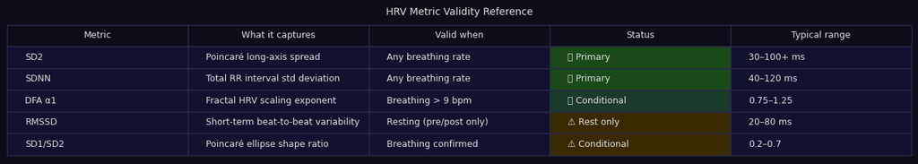

```python
# Metric validity reference — displayed as a styled table
metrics_ref = pd.DataFrame([
    ('SD2',      'Poincaré long-axis spread',          'Any breathing rate',    '✅ Primary',   '30–100+ ms'),
    ('SDNN',     'Total RR interval std deviation',    'Any breathing rate',    '✅ Primary',   '40–120 ms'),
    ('DFA α1',   'Fractal HRV scaling exponent',       'Breathing > 9 bpm',     '✅ Conditional','0.75–1.25'),
    ('RMSSD',    'Short-term beat-to-beat variability','Resting (pre/post only)','⚠️ Rest only', '20–80 ms'),
    ('SD1/SD2',  'Poincaré ellipse shape ratio',       'Breathing confirmed',   '⚠️ Conditional','0.2–0.7'),
], columns=['Metric', 'What it captures', 'Valid when', 'Status', 'Typical range'])

fig, ax = plt.subplots(figsize=(13, 2.4))
fig.patch.set_facecolor(BG)
ax.set_facecolor(BG)
ax.axis('off')
colours = {'✅ Primary': '#1a4a1a', '✅ Conditional': '#1a3a2a', '⚠️ Rest only': '#3a2a00', '⚠️ Conditional': '#3a2a00'}
tbl = ax.table(
    cellText=metrics_ref.values,
    colLabels=metrics_ref.columns,
    loc='center', cellLoc='left'
)
tbl.auto_set_font_size(False)
tbl.set_fontsize(9)
tbl.scale(1, 1.8)
for (row, col), cell in tbl.get_celld().items():
    cell.set_facecolor(BG if row == 0 else '#111130')
    cell.set_text_props(color=FG)
    cell.set_edgecolor('#2a2a4a')
    if row > 0 and col == 3:
        stat = metrics_ref.iloc[row-1]['Status']
        cell.set_facecolor(colours.get(stat, BG))
plt.title('HRV Metric Validity Reference', color=FG, pad=8, fontsize=10)
plt.tight_layout()
plt.savefig('../outputs/figures/doe_metric_table.png', dpi=120, bbox_inches='tight', facecolor=BG)
plt.show()
```

## What We Can Control: The 5 Acoustic Levers

These are the sound features the facilitator can tune — each with a known (or hypothesised) direction of effect on the ANS.

| Feature | Facilitator language | ANS direction | Mechanism | ⚠️ Medical flag |
| --- | --- | --- | --- | --- |
| **bass_energy** | How much low-frequency body vibration | ↓ SD2 at extremes; U-shaped | Vestibular saccule activation → hypothalamus → SNS | Sub-bass > 80 dB can cause inner ear discomfort. **Do not use with vestibular conditions or pacemakers.** |
| **lf_am_ratio** | Slow tension drone — how much the sound pulses very slowly (<4/sec) | ↓ SD2 (SNS↑) | Subcortical arousal; slow AM drives sustained attention → SNS tone | High lf_am_ratio = most activating. **Monitor HR. Avoid sustained high exposure in hypertension.** |
| **hf_am_ratio** | Breath-frequency wobble — sound oscillating at breathing speed | ↑ SD2 (PNS↑) | Vagal entrainment via respiratory pathway | Safe when below patient's distress threshold. **The primary PNS lever.** |
| **spec_centroid_hz** | Brightness / sharpness of the sound | ↓ SD2 at high values | Cortical alerting response; high-frequency content → startle pathway | Very high centroid (>3000 Hz) can cause auditory stress in hyperacusis. |
| **tempo_bpm** | Beat rate / pulse | Biphasic: slow↑PNS, fast↑SNS | Rhythmic entrainment of cardiac oscillations | Fast tempos >120 bpm: caution in cardiac patients. |

### The Design Space

We treat these 5 features as **independent variables (factors)** in our experiment. Each can be set to a **Low** or **High** level for a 3-minute measurement window.

```
Low level (−1)  = calming/grounding end of each feature's range
High level (+1) = activating/arousing end
```

This is the language of Design of Experiment. We explore *which factors matter most* before committing to a full map.

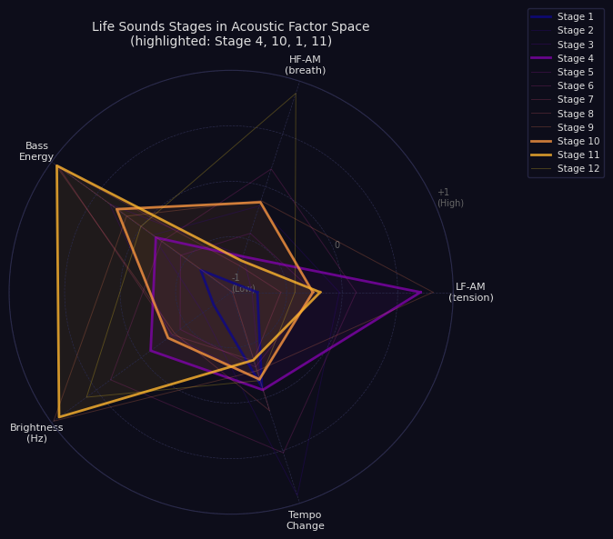

[output not shown]

```python
# Load Life Sounds features to show where real stages fall in factor space
ac_all = pd.read_csv('../outputs/life_sounds_features.csv')

FACTORS = ['lf_am_ratio', 'hf_am_ratio', 'bass_energy', 'spec_centroid_hz', 'tempo_change_rate']
FACTOR_LABELS = ['LF-AM\n(tension)', 'HF-AM\n(breath)', 'Bass\nEnergy', 'Brightness\n(Hz)', 'Tempo\nChange']
FACTOR_RANGES = {
    'lf_am_ratio':     (0.01, 0.35),
    'hf_am_ratio':     (0.01, 0.50),   # actual max ~0.47
    'bass_energy':     (0.02, 0.15),
    'spec_centroid_hz':(350,  1000),   # actual max ~992 Hz
    'tempo_change_rate':(0.0, 0.16),   # actual max ~0.154
}

def normalise(val, lo, hi):
    return float(np.clip(2 * (val - lo) / (hi - lo) - 1, -1, 1))

N = len(FACTORS)
angles = np.linspace(0, 2 * np.pi, N, endpoint=False).tolist()
angles += angles[:1]

HIGHLIGHT = ['Stage 4', 'Stage 10', 'Stage 1', 'Stage 11']
fig, ax = plt.subplots(figsize=(7, 7), subplot_kw=dict(polar=True))
fig.patch.set_facecolor(BG)
ax.set_facecolor(BG)
ax.set_thetagrids(np.degrees(angles[:-1]), labels=FACTOR_LABELS, color=FG, fontsize=8)
ax.set_ylim(-1, 1)
ax.set_yticks([-1, -0.5, 0, 0.5, 1])
ax.set_yticklabels(['-1\n(Low)', '', '0', '', '+1\n(High)'], color='#666', fontsize=7)
ax.grid(color='#2a2a4a', linestyle='--', linewidth=0.5)
ax.spines['polar'].set_color('#2a2a4a')

cmap = plt.cm.plasma
for i, row in ac_all.iterrows():
    vals = [normalise(row[f], *FACTOR_RANGES[f]) for f in FACTORS]
    vals += vals[:1]
    stage_num = i + 1
    colour = cmap(i / 12)
    alpha = 0.8 if row['stage'] in HIGHLIGHT else 0.25
    lw    = 2.0 if row['stage'] in HIGHLIGHT else 0.7
    ax.plot(angles, vals, color=colour, alpha=alpha, linewidth=lw, label=row['stage'])
    if row['stage'] in HIGHLIGHT:
        ax.fill(angles, vals, color=colour, alpha=0.08)

ax.legend(loc='upper right', bbox_to_anchor=(1.35, 1.15),
          fontsize=7.5, facecolor=BG, edgecolor='#2a2a4a', labelcolor=FG)
ax.set_title('Life Sounds Stages in Acoustic Factor Space\n(highlighted: Stage 4, 10, 1, 11)',
             color=FG, pad=20, fontsize=10)
plt.tight_layout()
plt.savefig('../outputs/figures/doe_factor_radar.png', dpi=130, bbox_inches='tight', facecolor=BG)
plt.show()
print('Each spike = one acoustic factor. Outer ring = activating. Centre = calming.')
print('Stage 4 profile is high LF-AM (tension). Stage 10 is high HF-AM (breath entrainment).')
```

## Phase 0 — Establishing the Personal Baseline

Before any experiment, you need to know *where this person starts*. The baseline is the anchor for everything else:

- What is their resting SD2? (defines "normal" for them)
- What is their resting DFA α1?
- What is their natural breathing rate?

**🔬 Protocol — Phase 0 (5 minutes, start of every session):**

1. Patient sits comfortably with Polar H10 fitted. No audio.
2. Eyes open or closed — patient's choice. Same choice every session.
3. Record 5 minutes of RR data.
4. Run the cell below.

> A resting RMSSD is valid here (patient is at rest, controlled breathing assumed). Use it as a reference — but note it's NOT valid during the session itself.

```python
# ─── REPLACE with real file path when DEMO_MODE = False ──────────────────────
np.random.seed(0)

if DEMO_MODE:
    # Synthetic 5-min resting baseline (physiologically typical)
    rr_rest_base = np.random.normal(900, 65, 330)          # ~67 bpm, ~5 min
    rr_rest_base = np.clip(rr_rest_base, 500, 1400)
    t_base = np.cumsum(rr_rest_base) / 1000.0
    print('⚠️  DEMO MODE: using synthetic baseline data')
else:
    t_raw, rr_raw = load_rr_polar_ecg(PATIENT_FILE)
    t_base, rr_rest_base = preprocess_rr(rr_raw, use_mode_filter=True, times_sec=t_raw)
    t_base = t_base[:np.searchsorted(t_base, 300)]         # first 5 min only
    rr_rest_base = rr_rest_base[:len(t_base)]
    print(f'Loaded: {PATIENT_FILE}')

# Compute baseline metrics
m0       = metrics_in_window(t_base, rr_rest_base, 0, t_base[-1])
BASELINE = {
    'sd2':     m0['sd2'],
    'dfa_a1':  m0['dfa_a1'],
    'rmssd':   m0['rmssd'],          # valid at rest
    'hr':      m0['mean_hr'],
    'br':      m0['breathing_rate'],
}
BASELINE['sdnn'] = compute_sdnn(rr_rest_base)

print()
print('═' * 50)
print(f"  PATIENT BASELINE — {PATIENT_ID}")
print('═' * 50)
for k, v in BASELINE.items():
    unit = 'ms' if k in ('sd2','rmssd','sdnn') else 'bpm' if k in ('hr','br') else ''
    flag = ''
    if k == 'sd2'    and v < 35:  flag = '  ← low; mild stress or deconditioning'
    if k == 'dfa_a1' and v < 0.75: flag = '  ⚠️ low — cardiac autonomic neuropathy?'
    if k == 'dfa_a1' and v > 1.5:  flag = '  ⚠️ high — may indicate vagal dominance/artefact'
    if k == 'br'     and v < 9:   flag = '  ← slow breathing; RMSSD-in-session unreliable'
    print(f"  {k:<10} {v:>7.2f} {unit}  {flag}")
print()
print('This baseline is the anchor. All session changes are relative to these values.')

# Safety gate
assert BASELINE['hr'] < HR_SAFE_UPPER,     f"❌ Resting HR {BASELINE['hr']:.0f} bpm already above safe ceiling {HR_SAFE_UPPER:.0f}. Do not proceed."
print(f'✅ Resting HR ({BASELINE["hr"]:.0f} bpm) within safe limits.')
```

```
⚠️  DEMO MODE: using synthetic baseline data

══════════════════════════════════════════════════
  PATIENT BASELINE — P_demo
══════════════════════════════════════════════════
  sd2          63.50 ms
  dfa_a1        0.56     ⚠️ low — cardiac autonomic neuropathy?
  rmssd        92.53 ms
  hr           66.64 bpm
  br            9.38 bpm
  sdnn         64.46 ms

This baseline is the anchor. All session changes are relative to these values.
✅ Resting HR (67 bpm) within safe limits.
```

## Phase 1 — Screening: Which Sound Factors Move This Patient?

### The problem

We have 5 acoustic factors. Running every combination would take 32 conditions (2⁵ = 32). At 3 minutes each, that's 96 minutes in one session — too long and physiologically unfeasible.

### The DoE solution: Fractional Factorial Design

A **2⁽⁵⁻²⁾ fractional factorial** tests 5 factors using only **8 conditions** (runs). We sacrifice the ability to detect two-factor interactions, but we learn which individual factors matter — and that's all we need at this stage.

- 8 conditions × 3 min audio = 24 min
- +1 min washout between each = 7 min
- +5 min baseline + 5 min recovery = 10 min
- **Total: ~41 minutes. One session.**

### What we learn

After fitting a simple linear model to the 8 measurements, we get the **main effect** of each factor: how many ms of SD2 does each factor shift, holding others constant? The top 2–3 are the ones worth mapping in Phase 2.

### Design shorthand

Each factor is coded as **−1** (low, calming) or **+1** (high, activating). The coding is just a convention — we translate to actual feature values per the ranges defined above.

**🔬 Protocol — Phase 1:**

```python
# 2^(5-2) Resolution III fractional factorial
# Generators: D = A·B, E = A·C
# Factors: A=lf_am, B=hf_am, C=bass, D=centroid, E=tempo
# −1 = low (calming), +1 = high (activating)

FACTOR_COLS = ['lf_am', 'hf_am', 'bass', 'centroid', 'tempo']

design_coded = np.array([
    [-1, -1, -1,  1,  1],   # Run 1
    [ 1, -1, -1, -1, -1],   # Run 2
    [-1,  1, -1, -1,  1],   # Run 3
    [ 1,  1, -1,  1, -1],   # Run 4
    [-1, -1,  1,  1, -1],   # Run 5
    [ 1, -1,  1, -1,  1],   # Run 6
    [-1,  1,  1, -1, -1],   # Run 7
    [ 1,  1,  1,  1,  1],   # Run 8
])

# Map coded levels to actual acoustic values
FACTOR_LO = {'lf_am': 0.05, 'hf_am': 0.05, 'bass': 0.03, 'centroid': 400, 'tempo': 45}
FACTOR_HI = {'lf_am': 0.30, 'hf_am': 0.28, 'bass': 0.14, 'centroid': 850, 'tempo': 110}

def decode(coded_val, lo, hi):
    return lo + (coded_val + 1) / 2 * (hi - lo)

rows_actual = []
for run in design_coded:
    row = {col: decode(run[i], FACTOR_LO[col], FACTOR_HI[col])
           for i, col in enumerate(FACTOR_COLS)}
    rows_actual.append(row)

design_df = pd.DataFrame(rows_actual)
design_df.insert(0, 'Run', range(1, 9))
design_df_coded = pd.DataFrame(design_coded, columns=FACTOR_COLS)
design_df_coded.insert(0, 'Run', range(1, 9))

print('PHASE 1 — SCREENING DESIGN MATRIX')
print('Coded levels (−1 = Low, +1 = High):')
print(design_df_coded.to_string(index=False))
print()
print('Actual acoustic values to target:')
print(design_df.round(3).to_string(index=False))
print()
print('Each row = one 3-minute audio segment to prepare.')
print('Tip: map these to the closest Life Sounds stage or create custom blends.')
```

```
PHASE 1 — SCREENING DESIGN MATRIX
Coded levels (−1 = Low, +1 = High):
 Run  lf_am  hf_am  bass  centroid  tempo
   1     -1     -1    -1         1      1
   2      1     -1    -1        -1     -1
   3     -1      1    -1        -1      1
   4      1      1    -1         1     -1
   5     -1     -1     1         1     -1
   6      1     -1     1        -1      1
   7     -1      1     1        -1     -1
   8      1      1     1         1      1

Actual acoustic values to target:
 Run  lf_am  hf_am  bass  centroid  tempo
   1   0.05   0.05  0.03     850.0  110.0
   2   0.30   0.05  0.03     400.0   45.0
   3   0.05   0.28  0.03     400.0  110.0
   4   0.30   0.28  0.03     850.0   45.0
   5   0.05   0.05  0.14     850.0   45.0
   6   0.30   0.05  0.14     400.0  110.0
   7   0.05   0.28  0.14     400.0   45.0
   8   0.30   0.28  0.14     850.0  110.0

Each row = one 3-minute audio segment to prepare.
Tip: map these to the closest Life Sounds stage or create custom blends.
```

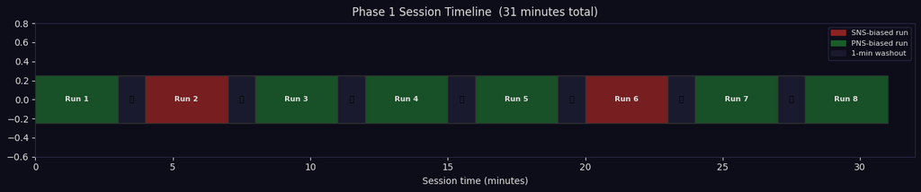

```python
# Visualise the Phase 1 session timeline
fig, ax = plt.subplots(figsize=(14, 3))
fig.patch.set_facecolor(BG)
ax.set_facecolor(BG)

t = 0
for i in range(8):
    # Audio segment (3 min)
    sns_pns = design_coded[i, 0] - design_coded[i, 1]  # lf_am - hf_am → proxy for SNS
    colour = '#8b2222' if sns_pns > 0 else '#1a5c2a'
    ax.barh(0, 3, left=t, height=0.5, color=colour, alpha=0.85, edgecolor='#333')
    ax.text(t + 1.5, 0, f'Run {i+1}', ha='center', va='center', color=FG, fontsize=8, fontweight='bold')
    t += 3
    # Washout (1 min)
    if i < 7:
        ax.barh(0, 1, left=t, height=0.5, color='#1a1a2e', edgecolor='#333')
        ax.text(t + 0.5, 0, '💤', ha='center', va='center', fontsize=9)
        t += 1

ax.set_xlim(0, t + 1)
ax.set_ylim(-0.6, 0.8)
ax.set_xlabel('Session time (minutes)', color=FG)
ax.tick_params(colors=FG)
for sp in ax.spines.values(): sp.set_edgecolor('#2a2a4a')
from matplotlib.patches import Patch
legend = [Patch(color='#8b2222', label='SNS-biased run'),
          Patch(color='#1a5c2a', label='PNS-biased run'),
          Patch(color='#1a1a2e', label='1-min washout')]
ax.legend(handles=legend, loc='upper right', facecolor=BG, edgecolor='#2a2a4a', labelcolor=FG, fontsize=8)
ax.set_title(f'Phase 1 Session Timeline  ({t} minutes total)', color=FG, pad=8)
plt.tight_layout()
plt.savefig('../outputs/figures/doe_phase1_timeline.png', dpi=130, bbox_inches='tight', facecolor=BG)
plt.show()
```

```python
# ─── In a real session: replace y_sd2 and y_dfa with measured values ──────────
# y_sd2 = np.array([measured SD2 for Run 1..8])
# y_dfa = np.array([measured DFA α1 for Run 1..8])

np.random.seed(42)

def patient_sd2(lf, hf, bass, centroid, tempo, baseline, noise_std=5.0):
    """Synthetic physiological model — unknown to facilitator.
    Replace with measured data from real session.
    Internally normalised so coefficients reflect ms of SD2 change per unit of each factor."""
    lf_n   = (lf - 0.175) / 0.125      # [0.05, 0.30] → [-1, +1]
    hf_n   = (hf - 0.165) / 0.115      # [0.05, 0.28] → [-1, +1]
    bass_n = (bass - 0.085) / 0.055    # [0.03, 0.14] → [-1, +1]
    cnt_n  = (centroid - 625) / 225    # [400, 850]   → [-1, +1]
    tmp_n  = (tempo - 77.5) / 32.5    # [45, 110]    → [-1, +1]
    effect = (
        -35 * lf_n             # LF-AM: primary SNS driver → lowers HRV
        + 28 * hf_n            # HF-AM: PNS entrainment → raises HRV
        - 10 * bass_n          # bass: vestibular saccule stress
        -  6 * cnt_n           # brightness: cortical arousal
        -  4 * tmp_n
        - 12 * lf_n * hf_n    # interaction: antagonistic — both high = mixed signal
        -  6 * lf_n**2         # nonlinearity: extreme LF is disproportionately activating
        +  4 * hf_n**2         # nonlinearity: extreme HF has diminishing returns
    )
    return float(baseline + effect + np.random.normal(0, noise_std))

def patient_dfa(lf, hf, bass, baseline_dfa=0.93, noise_std=0.04):
    lf_n   = (lf - 0.175) / 0.125
    hf_n   = (hf - 0.165) / 0.115
    bass_n = (bass - 0.085) / 0.055
    effect = -0.15 * lf_n + 0.20 * hf_n - 0.06 * bass_n
    return float(baseline_dfa + effect + np.random.normal(0, noise_std))

if DEMO_MODE:
    y_sd2 = np.array([patient_sd2(
        row['lf_am'], row['hf_am'], row['bass'],
        row['centroid'], row['tempo'], BASELINE['sd2'])
        for _, row in design_df.iterrows()])
    y_dfa = np.array([patient_dfa(row['lf_am'], row['hf_am'], row['bass'])
                      for _, row in design_df.iterrows()])
    print('⚠️  DEMO MODE: synthetic ANS responses generated')
else:
    # ── Load real session file and slice each 3-min window ────────────────
    # Adjust t_starts to match your actual session start times
    t_starts = [10, 14, 18, 22, 26, 30, 34, 38]  # ← minutes from recording start
    t_raw, rr_raw = load_rr_polar_ecg(PATIENT_FILE)
    t_clean, rr_clean = preprocess_rr(rr_raw, use_mode_filter=True, times_sec=t_raw)
    y_sd2, y_dfa = [], []
    for t0_min in t_starts:
        t0, t1 = t0_min * 60, (t0_min + 3) * 60
        m = metrics_in_window(t_clean, rr_clean, t0, t1)
        y_sd2.append(m['sd2']); y_dfa.append(m['dfa_a1'])
    y_sd2, y_dfa = np.array(y_sd2), np.array(y_dfa)

# ── Fit linear main-effects model (SD2 ~ lf_am + hf_am + bass + centroid + tempo) ──
X_coded = design_coded                        # 8×5, coded ±1
X_ols   = np.column_stack([np.ones(8), X_coded])  # add intercept

def fit_ols(y):
    beta, *_ = np.linalg.lstsq(X_ols, y, rcond=None)
    y_hat    = X_ols @ beta
    resid    = y - y_hat
    n, p     = X_ols.shape
    s2       = resid @ resid / (n - p)
    cov      = s2 * np.linalg.inv(X_ols.T @ X_ols)
    se       = np.sqrt(np.diag(cov))
    t_stat   = beta / se
    p_val    = 2 * stats.t.sf(np.abs(t_stat), df=n-p)
    r2       = 1 - (resid @ resid) / ((y - y.mean()) @ (y - y.mean()))
    return beta, se, t_stat, p_val, r2, y_hat

beta_sd2, se_sd2, t_sd2, p_sd2, r2_sd2, yhat_sd2 = fit_ols(y_sd2)
beta_dfa, se_dfa, t_dfa, p_dfa, r2_dfa, yhat_dfa = fit_ols(y_dfa)

labels = ['Intercept'] + FACTOR_COLS
print('PHASE 1 — LINEAR MODEL RESULTS')
print('=' * 80)
print(f"{'Factor':<12} {'β SD2':>9} {'SE':>7} {'p':>8}   {'β DFA α1':>9} {'SE':>7} {'p':>8}")
print('-' * 80)
for i, lbl in enumerate(labels):
    sig_s = '*' if p_sd2[i] < 0.05 else (' ·' if p_sd2[i] < 0.1 else '')
    sig_d = '*' if p_dfa[i] < 0.05 else (' ·' if p_dfa[i] < 0.1 else '')
    print(f"{lbl:<12} {beta_sd2[i]:>+9.2f} {se_sd2[i]:>7.2f} {p_sd2[i]:>8.3f}{sig_s:2s}  {beta_dfa[i]:>+9.4f} {se_dfa[i]:>7.4f} {p_dfa[i]:>8.3f}{sig_d}")
print()
print(f'R² SD2: {r2_sd2:.3f}   R² DFA α1: {r2_dfa:.3f}')
print('* p < 0.05   · p < 0.10   (8-run design has limited power — direction matters as much as p-value)')
```

```
⚠️  DEMO MODE: synthetic ANS responses generated
PHASE 1 — LINEAR MODEL RESULTS
================================================================================
Factor           β SD2      SE        p    β DFA α1      SE        p
--------------------------------------------------------------------------------
Intercept       +64.25    1.12    0.000*     +0.9059  0.0154    0.000*
lf_am           -35.36    1.12    0.001*     -0.1499  0.0154    0.010*
hf_am           +30.89    1.12    0.001*     +0.1919  0.0154    0.006*
bass            -10.41    1.12    0.011*     -0.0755  0.0154    0.039*
centroid        -17.56    1.12    0.004*     +0.0115  0.0154    0.532
tempo            -4.66    1.12    0.053 ·    -0.0100  0.0154    0.582

R² SD2: 0.999   R² DFA α1: 0.993
* p < 0.05   · p < 0.10   (8-run design has limited power — direction matters as much as p-value)
```

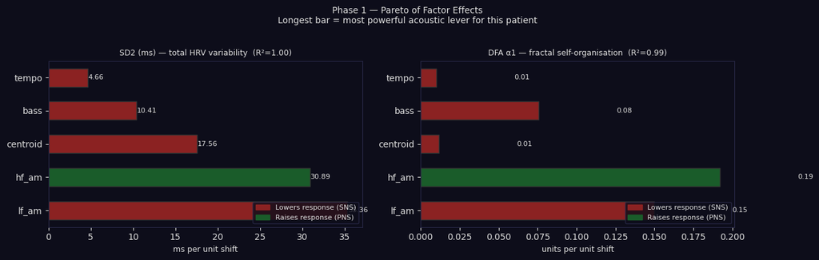

```
→ Top 2 factors for Phase 2: lf_am  and  hf_am
  These will be mapped in detail in the response surface experiment.
```

```python
# Pareto chart of absolute factor effects (SD2 model)
effects_sd2 = np.abs(beta_sd2[1:])   # exclude intercept
effects_dfa = np.abs(beta_dfa[1:])
order = np.argsort(effects_sd2)[::-1]

fig, axes = plt.subplots(1, 2, figsize=(13, 4))
fig.patch.set_facecolor(BG)

for ax, effects, title, unit, r2_val in zip(
        axes,
        [effects_sd2, effects_dfa],
        ['SD2 (ms) — total HRV variability', 'DFA α1 — fractal self-organisation'],
        ['ms per unit shift', 'units per unit shift'],
        [r2_sd2, r2_dfa]):
    ax.set_facecolor(BG)
    cols = [('#8b2222' if beta_sd2[1+order[i]] < 0 else '#1a5c2a') for i in range(len(order))]
    bars = ax.barh([FACTOR_COLS[j] for j in order], effects[order],
                   color=cols, edgecolor='#333', height=0.55)
    ax.set_xlabel(unit, color=FG, fontsize=9)
    ax.set_title(f'{title}  (R²={r2_val:.2f})', color=FG, fontsize=9)
    ax.tick_params(colors=FG)
    for sp in ax.spines.values(): sp.set_edgecolor('#2a2a4a')
    for bar, val in zip(bars, effects[order]):
        ax.text(val + 0.05, bar.get_y() + bar.get_height()/2,
                f'{val:.2f}', va='center', color=FG, fontsize=8)
    from matplotlib.patches import Patch
    ax.legend(handles=[Patch(color='#8b2222', label='Lowers response (SNS)'),
                        Patch(color='#1a5c2a', label='Raises response (PNS)')],
              facecolor=BG, edgecolor='#2a2a4a', labelcolor=FG, fontsize=8, loc='lower right')

plt.suptitle('Phase 1 — Pareto of Factor Effects\n'
             'Longest bar = most powerful acoustic lever for this patient',
             color=FG, fontsize=10, y=1.02)
plt.tight_layout()
plt.savefig('../outputs/figures/doe_phase1_pareto.png', dpi=130, bbox_inches='tight', facecolor=BG)
plt.show()

# Identify top 2 factors for Phase 2
top2_idx  = np.argsort(effects_sd2)[-2:][::-1]
TOP_FACTORS = [FACTOR_COLS[i] for i in top2_idx]
print(f'\n→ Top 2 factors for Phase 2: {TOP_FACTORS[0]}  and  {TOP_FACTORS[1]}')
print('  These will be mapped in detail in the response surface experiment.')
```

## Decision Gate — When to Move to Phase 2

Before running Phase 2, check all three conditions:

| Gate | Criterion | Why |
| --- | --- | --- |
| **Model quality** | R² > 0.5 for SD2 | Below 0.5 = too much noise or a factor was mis-set |
| **Safety** | No run produced SD2 < 30 ms | Below 30 ms = severe vagal withdrawal; re-check protocol |
| **Top factors distinct** | Top 2 effects differ by > 30% | If all effects are similar, suspect execution error |

If a gate fails: recheck the audio segments, make sure the Polar H10 had good contact, and confirm the run timing matched the design matrix before re-running Phase 1.

## Phase 2 — Response Surface Mapping

Now we know *which* factors matter. Phase 2 answers: *how do they interact, and where is the sweet spot?*

### Central Composite Design (CCD)

- 4 factorial corners (±1, ±1)
- 4 axial points (±α, 0) and (0, ±α), where α = 1.414 for rotatable design
- 3 centre replicates (0, 0) — gives an estimate of pure experimental error

This allows us to fit a **quadratic model** including curvature and interaction:

> SD2 = β₀ + β₁·F₁ + β₂·F₂ + β₁₂·F₁·F₂ + β₁₁·F₁² + β₂₂·F₂² + ε

This is the simplest model that can find an **interior optimum** (a bowl or hill shape), not just a corner.

**🔬 Protocol — Phase 2 (similar to Phase 1):** Same structure: 11 conditions × 3 min each + 1 min washouts + 5 min pre/post. Total: ~11×3 + 10×1 + 10 = **53 minutes**.

```python
alpha = np.sqrt(2)   # rotatability for k=2

# CCD in coded space: [F1, F2]
ccd_coded = np.array([
    [-1,     -1    ],  # Factorial
    [ 1,     -1    ],
    [-1,      1    ],
    [ 1,      1    ],
    [-alpha,  0    ],  # Axial
    [ alpha,  0    ],
    [ 0,     -alpha],
    [ 0,      alpha],
    [ 0,      0    ],  # Centre replicates
    [ 0,      0    ],
    [ 0,      0    ],
])

F1_name, F2_name = TOP_FACTORS

# Map coded to actual values
def ccd_actual(coded):
    lo1, hi1 = FACTOR_LO[F1_name], FACTOR_HI[F1_name]
    lo2, hi2 = FACTOR_LO[F2_name], FACTOR_HI[F2_name]
    val1 = lo1 + (coded[0] + alpha) / (2 * alpha) * (hi1 - lo1)
    val2 = lo2 + (coded[1] + alpha) / (2 * alpha) * (hi2 - lo2)
    return val1, val2

# Synthetic Phase 2 responses (demo only)
np.random.seed(7)
y2_sd2 = []
for pt in ccd_coded:
    v1, v2 = ccd_actual(pt)
    # Use patient model with other factors fixed at their midpoints
    lf  = v1 if F1_name == 'lf_am'  else (FACTOR_LO['lf_am']  + FACTOR_HI['lf_am'])  / 2
    hf  = v1 if F1_name == 'hf_am'  else (FACTOR_LO['hf_am']  + FACTOR_HI['hf_am'])  / 2
    if F2_name == 'hf_am':  hf  = v2
    if F2_name == 'lf_am':  lf  = v2
    bass = (FACTOR_LO['bass'] + FACTOR_HI['bass']) / 2
    cent = (FACTOR_LO['centroid'] + FACTOR_HI['centroid']) / 2
    tmp  = (FACTOR_LO['tempo'] + FACTOR_HI['tempo']) / 2
    y2_sd2.append(patient_sd2(lf, hf, bass, cent, tmp, BASELINE['sd2']))

y2_sd2 = np.array(y2_sd2)

# Fit quadratic model
poly    = PolynomialFeatures(degree=2, include_bias=True)
X2_poly = poly.fit_transform(ccd_coded)
rs_model = LinearRegression(fit_intercept=False).fit(X2_poly, y2_sd2)
y2_pred  = rs_model.predict(X2_poly)
r2_rs    = r2_score(y2_sd2, y2_pred)
rmse_rs  = np.sqrt(mean_squared_error(y2_sd2, y2_pred))

print(f'PHASE 2 — RESPONSE SURFACE MODEL  ({F1_name} × {F2_name})')
print(f'R² = {r2_rs:.3f}   RMSE = {rmse_rs:.2f} ms')
print()
print(f'Coefficients:')
for name, coef in zip(poly.get_feature_names_out([F1_name[:4], F2_name[:4]]),
                       rs_model.coef_):
    print(f'  {name:<15} {coef:+.3f}')
print()
print('R² > 0.7 = good surface. R² > 0.85 = excellent. Below 0.6 = add more points.')
```

```
PHASE 2 — RESPONSE SURFACE MODEL  (lf_am × hf_am)
R² = 0.984   RMSE = 3.40 ms

Coefficients:
  1               +65.152
  lf_a            -25.163
  hf_a            +17.759
  lf_a^2          -3.496
  lf_a hf_a       -2.836
  hf_a^2          +0.293

R² > 0.7 = good surface. R² > 0.85 = excellent. Below 0.6 = add more points.
```

```
★  Optimal settings for maximum PNS response:
   lf_am: 0.050
   hf_am: 0.280
   Predicted SD2: 125.1 ms

⚠️  Safe floor (SD2 ≥ 43 ms): avoid orange-dashed region.
   The facilitator should NEVER target settings below this boundary.
```

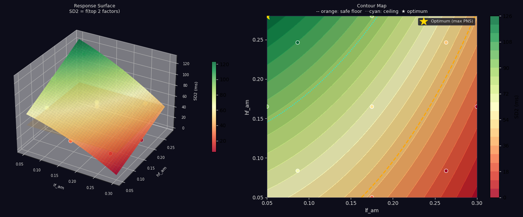

```python
# Grid for surface prediction
g1 = np.linspace(-alpha, alpha, 40)
g2 = np.linspace(-alpha, alpha, 40)
G1, G2 = np.meshgrid(g1, g2)
X_grid_coded = np.column_stack([G1.ravel(), G2.ravel()])
X_grid_poly  = poly.transform(X_grid_coded)
Z            = rs_model.predict(X_grid_poly).reshape(G1.shape)

# Map grid to actual feature values for axis labels
lo1, hi1 = FACTOR_LO[F1_name], FACTOR_HI[F1_name]
lo2, hi2 = FACTOR_LO[F2_name], FACTOR_HI[F2_name]
G1_actual = lo1 + (G1 + alpha) / (2*alpha) * (hi1 - lo1)
G2_actual = lo2 + (G2 + alpha) / (2*alpha) * (hi2 - lo2)

# Safe zone: SD2 >= BASELINE['sd2'] - 20 ms  (don't drop more than 20 ms)
SD2_FLOOR   = BASELINE['sd2'] - 20
SD2_CEILING = BASELINE['sd2'] + 25

fig = plt.figure(figsize=(15, 6))
fig.patch.set_facecolor(BG)

# ─ 3D surface ─────────────────────────────────────────────────────────────────
ax3d = fig.add_subplot(121, projection='3d')
ax3d.set_facecolor(BG)
surf = ax3d.plot_surface(G1_actual, G2_actual, Z, cmap='RdYlGn',
                          alpha=0.85, linewidth=0, antialiased=True)
# Mark safe zone floor as horizontal plane
ax3d.plot_surface(G1_actual, G2_actual,
                  np.full_like(Z, SD2_FLOOR), alpha=0.15, color='orange')
ccd_x, ccd_y = zip(*[ccd_actual(pt) for pt in ccd_coded])
ax3d.scatter(list(ccd_x), list(ccd_y), y2_sd2,
             c=y2_sd2, cmap='RdYlGn', s=60, zorder=5, edgecolors='white', linewidths=0.5)
ax3d.set_xlabel(F1_name, color=FG, fontsize=8); ax3d.set_ylabel(F2_name, color=FG, fontsize=8)
ax3d.set_zlabel('SD2 (ms)', color=FG, fontsize=8)
ax3d.set_title('Response Surface\nSD2 = f(top 2 factors)', color=FG, fontsize=9)
ax3d.tick_params(colors=FG, labelsize=7)
fig.colorbar(surf, ax=ax3d, shrink=0.5, pad=0.1).ax.yaxis.set_tick_params(color=FG)

# ─ Contour + safe zone ────────────────────────────────────────────────────────
ax2d = fig.add_subplot(122)
ax2d.set_facecolor(BG)
cs  = ax2d.contourf(G1_actual, G2_actual, Z, levels=20, cmap='RdYlGn', alpha=0.85)
plt.colorbar(cs, ax=ax2d, label='SD2 (ms)').ax.yaxis.set_tick_params(color=FG)
# Safe zone boundary
ax2d.contour(G1_actual, G2_actual, Z, levels=[SD2_FLOOR],
             colors='orange', linewidths=2, linestyles='--')
ax2d.contour(G1_actual, G2_actual, Z, levels=[SD2_CEILING],
             colors='cyan', linewidths=1.5, linestyles=':')
# Find optimum
opt_idx = np.unravel_index(np.argmax(Z), Z.shape)
ax2d.scatter(G1_actual[opt_idx], G2_actual[opt_idx], marker='*',
             s=250, color='gold', zorder=10, label='Optimum (max PNS)')
ax2d.scatter(*zip(*[ccd_actual(pt) for pt in ccd_coded]),
             c=y2_sd2, cmap='RdYlGn', s=50, edgecolors='white', linewidths=0.8, zorder=9)
ax2d.set_xlabel(F1_name, color=FG); ax2d.set_ylabel(F2_name, color=FG)
ax2d.set_title('Contour Map\n-- orange: safe floor  ···cyan: ceiling  ★ optimum', color=FG, fontsize=9)
ax2d.tick_params(colors=FG)
for sp in ax2d.spines.values(): sp.set_edgecolor('#2a2a4a')
ax2d.legend(facecolor=BG, edgecolor='#2a2a4a', labelcolor=FG, fontsize=8)

opt_v1, opt_v2 = G1_actual[opt_idx], G2_actual[opt_idx]
print(f'\n★  Optimal settings for maximum PNS response:')
print(f'   {F1_name}: {opt_v1:.3f}')
print(f'   {F2_name}: {opt_v2:.3f}')
print(f'   Predicted SD2: {Z[opt_idx]:.1f} ms')
print(f'\n⚠️  Safe floor (SD2 ≥ {SD2_FLOOR:.0f} ms): avoid orange-dashed region.')
print(f'   The facilitator should NEVER target settings below this boundary.')

plt.tight_layout()
plt.savefig('../outputs/figures/doe_phase2_surface.png', dpi=130, bbox_inches='tight', facecolor=BG)
plt.show()
```

## Phase 3 — Robust Optimisation (Taguchi Approach)

### The clinical problem

The Phase 2 optimum is the best sound setting *on average*. But patients come to sessions with varying states: poor sleep, a stressful morning, mild illness. A setting that produces a strong PNS response on a good day may be ineffective — or even counterproductive — on a difficult day.

**Autonomic resilience** means the patient's response is *robust to daily disturbances*. We want to find sound settings that consistently produce a positive ANS shift even when life is hard.

### Taguchi's insight: separate control from noise

| Factor type | Example | We can... |
| --- | --- | --- |
| **Control factor** (C) | lf_am_ratio, hf_am_ratio | Choose and hold |
| **Noise / Disturbance** (N) | Pre-session stress, sleep quality | Measure but not control |

Taguchi's method: run the control experiment **across multiple noise conditions**. Find the control settings where the SD2 response is highest *and most consistent* regardless of the patient's daily state.

The objective: maximise the **Signal-to-Noise Ratio (SNR)**

> **SNR (larger-is-better) = −10 · log₁₀ ( mean(1/y²) )**

High SNR = good response even on bad days = **resilience**.

### The disturbance factor we use

**Pre-session stress** (self-report 0–10) collected at session start. This is the primary "noise" variable we track. Sleep quality is secondary. Both are collected via the standard self-report form.

Over multiple sessions, we observe each design point under different disturbance levels and compute the SNR across those observations.

```python
# Taguchi L9 inner array: 2 control factors × 3 levels
# C1 = top factor 1 (e.g. lf_am)  Levels: Low / Mid / High
# C2 = top factor 2 (e.g. hf_am)  Levels: Low / Mid / High

CF_LEVELS = {
    F1_name: [FACTOR_LO[F1_name],
              (FACTOR_LO[F1_name] + FACTOR_HI[F1_name]) / 2,
              FACTOR_HI[F1_name]],
    F2_name: [FACTOR_LO[F2_name],
              (FACTOR_LO[F2_name] + FACTOR_HI[F2_name]) / 2,
              FACTOR_HI[F2_name]],
}
LEVEL_LABELS = ['Low', 'Mid', 'High']

L9 = [(i, j) for i in range(3) for j in range(3)]   # 3×3 full factorial = L9 here

# Outer array: 4 noise conditions (2×2 disturbance combinations)
# N1 = pre-stress: Low (0-3), High (7-10)
# N2 = sleep quality: Good (4-5), Poor (1-2)
NOISE_CONDITIONS = [
    {'label': 'Low stress, Good sleep', 'stress_eff': 0.0,  'sleep_eff': 0.0},
    {'label': 'Low stress, Poor sleep', 'stress_eff': 0.0,  'sleep_eff': -5.0},
    {'label': 'High stress, Good sleep','stress_eff': -8.0, 'sleep_eff': 0.0},
    {'label': 'High stress, Poor sleep','stress_eff': -8.0, 'sleep_eff': -5.0},
]

np.random.seed(21)
taguchi_rows = []
for (i, j) in L9:
    v1 = CF_LEVELS[F1_name][i]
    v2 = CF_LEVELS[F2_name][j]
    lf = v1 if F1_name == 'lf_am' else (FACTOR_LO['lf_am']+FACTOR_HI['lf_am'])/2
    hf = v1 if F1_name == 'hf_am' else (FACTOR_LO['hf_am']+FACTOR_HI['hf_am'])/2
    if F2_name == 'hf_am': hf = v2
    if F2_name == 'lf_am': lf = v2
    bass = (FACTOR_LO['bass']+FACTOR_HI['bass'])/2
    cent = (FACTOR_LO['centroid']+FACTOR_HI['centroid'])/2
    tmp  = (FACTOR_LO['tempo']+FACTOR_HI['tempo'])/2

    y_noise = []
    for nc in NOISE_CONDITIONS:
        sd2_val = (patient_sd2(lf, hf, bass, cent, tmp, BASELINE['sd2'])
                   + nc['stress_eff'] + nc['sleep_eff'])
        sd2_val = max(sd2_val, 15)  # floor (physiological minimum)
        y_noise.append(sd2_val)

    y_arr   = np.array(y_noise)
    mu      = y_arr.mean()
    snr     = -10 * np.log10(np.mean(1.0 / y_arr**2))   # larger-is-better

    taguchi_rows.append({
        F1_name: LEVEL_LABELS[i], F2_name: LEVEL_LABELS[j],
        'Mean_SD2': mu, 'SNR': snr,
        **{nc['label'][:20]: y for nc, y in zip(NOISE_CONDITIONS, y_noise)}
    })

tag_df = pd.DataFrame(taguchi_rows)
print('PHASE 3 — TAGUCHI L9 RESULTS (SD2 across 4 noise conditions)')
print('=' * 75)
print(tag_df[[F1_name, F2_name, 'Mean_SD2', 'SNR']
             + [nc['label'][:20] for nc in NOISE_CONDITIONS]].to_string(index=False, float_format='%.1f'))
```

```
PHASE 3 — TAGUCHI L9 RESULTS (SD2 across 4 noise conditions)
===========================================================================
lf_am hf_am  Mean_SD2  SNR  Low stress, Good sle  Low stress, Poor sle  High stress, Good sl  High stress, Poor sl
  Low   Low      49.5 33.5                  56.2                  50.9                  53.7                  37.2
  Low   Mid      84.2 38.4                  96.2                  78.9                  83.5                  78.3
  Low  High     132.3 42.4                 142.1                 131.4                 125.4                 130.4
  Mid   Low      34.5 30.0                  47.6                  31.1                  35.0                  24.3
  Mid   Mid      56.0 34.8                  64.3                  59.8                  49.1                  50.8
  Mid  High      83.4 38.3                  90.2                  85.6                  85.2                  72.6
 High   Low      15.0 23.5                  15.0                  15.0                  15.0                  15.0
 High   Mid      19.7 25.6                  20.2                  21.0                  22.3                  15.4
 High  High      34.1 30.5                  35.6                  28.8                  36.5                  35.7
```

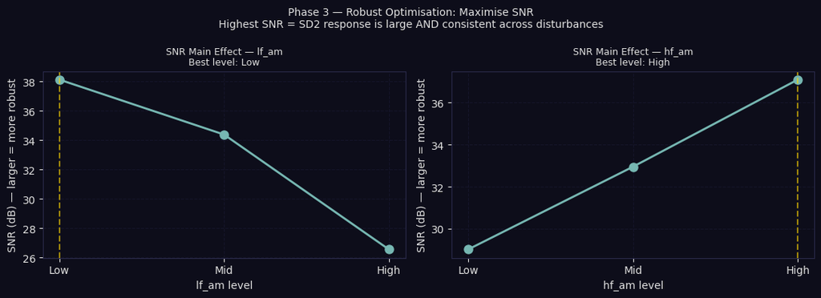

```
★  ROBUST OPTIMAL SETTINGS:
   lf_am: Low  →  0.050
   hf_am: High  →  0.280

These are the settings that produce the best ANS response on both good AND bad days.
Use them as the default prescription for therapeutic sessions going forward.

⚠️ Medical Flag: If the robust optimum is at the High level of an activating factor,
   request clinical review before using it with patients who have cardiac or
   hypertension-related diagnoses. High stimulation may be unsafe on high-stress days.
```

```python
# Main effects of control factors on SNR → choose levels that maximise SNR

snr_vals = tag_df['SNR'].values.reshape(3, 3)  # [C1_level, C2_level]

snr_C1 = snr_vals.mean(axis=1)   # average over C2
snr_C2 = snr_vals.mean(axis=0)   # average over C1

best_C1 = LEVEL_LABELS[np.argmax(snr_C1)]
best_C2 = LEVEL_LABELS[np.argmax(snr_C2)]

fig, axes = plt.subplots(1, 2, figsize=(11, 4))
fig.patch.set_facecolor(BG)

for ax, snr_arr, fname, best in zip(
        axes, [snr_C1, snr_C2], [F1_name, F2_name], [best_C1, best_C2]):
    ax.set_facecolor(BG)
    ax.plot(LEVEL_LABELS, snr_arr, 'o-', color=ACC, linewidth=2, markersize=8)
    ax.axvline(LEVEL_LABELS.index(best), color='gold', linestyle='--', alpha=0.6)
    ax.set_xlabel(f'{fname} level', color=FG)
    ax.set_ylabel('SNR (dB) — larger = more robust', color=FG)
    ax.set_title(f'SNR Main Effect — {fname}\nBest level: {best}', color=FG, fontsize=9)
    ax.tick_params(colors=FG)
    for sp in ax.spines.values(): sp.set_edgecolor('#2a2a4a')
    ax.grid(color='#1e1e3a', linestyle='--', alpha=0.5)

plt.suptitle('Phase 3 — Robust Optimisation: Maximise SNR\n'
             'Highest SNR = SD2 response is large AND consistent across disturbances',
             color=FG, fontsize=10)
plt.tight_layout()
plt.savefig('../outputs/figures/doe_phase3_snr.png', dpi=130, bbox_inches='tight', facecolor=BG)
plt.show()

print(f'\n★  ROBUST OPTIMAL SETTINGS:')
print(f'   {F1_name}: {best_C1}  →  {CF_LEVELS[F1_name][LEVEL_LABELS.index(best_C1)]:.3f}')
print(f'   {F2_name}: {best_C2}  →  {CF_LEVELS[F2_name][LEVEL_LABELS.index(best_C2)]:.3f}')
print()
print('These are the settings that produce the best ANS response on both good AND bad days.')
print('Use them as the default prescription for therapeutic sessions going forward.')
print()
print('⚠️ Medical Flag: If the robust optimum is at the High level of an activating factor,')
print('   request clinical review before using it with patients who have cardiac or')
print('   hypertension-related diagnoses. High stimulation may be unsafe on high-stress days.')
```

## Adaptive Sampling — Where Does the Model Need More Data?

After Phase 2, the response surface model covers the factor space *evenly*. But the model is not equally confident everywhere — near the safe-zone boundary and around the optimum, we need higher precision.

**Gaussian Process (GP) regression** gives us a prediction *plus an uncertainty estimate* at every point. High uncertainty = the model is guessing. We focus the next session's measurements on those regions.

This is especially useful in later sessions when the patient's response has shifted (autonomic adaptation) — the GP tells us where the current model is no longer accurate.

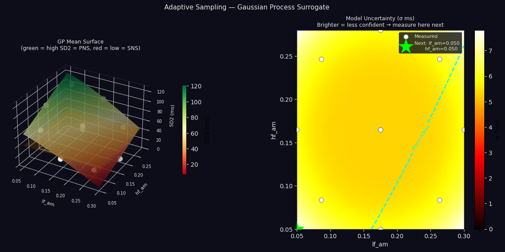

```
→ Recommended next measurement point:
   lf_am: 0.050   hf_am: 0.050
   Uncertainty (σ): 7.81 ms

   Add this condition to your next session to sharpen the model.
```

```python
# Gaussian Process surrogate trained on Phase 2 data
# Kernel: smooth RBF + white noise for measurement uncertainty
kernel = ConstantKernel(1.0) * RBF(length_scale=1.0) + WhiteKernel(noise_level=0.1)
gp = GaussianProcessRegressor(kernel=kernel, n_restarts_optimizer=5, normalize_y=True)
gp.fit(ccd_coded, y2_sd2)

# Predict mean and uncertainty over the whole factor grid
X_gp_grid = np.column_stack([G1.ravel(), G2.ravel()])
Z_gp_mean, Z_gp_std = gp.predict(X_gp_grid, return_std=True)
Z_gp_mean = Z_gp_mean.reshape(G1.shape)
Z_gp_std  = Z_gp_std.reshape(G1.shape)

# Next recommended measurement: highest uncertainty, inside safe zone
safe_mask   = Z_gp_mean > SD2_FLOOR
gp_std_safe = Z_gp_std.copy(); gp_std_safe[~safe_mask] = 0
next_idx    = np.unravel_index(np.argmax(gp_std_safe), Z_gp_std.shape)
next_v1     = G1_actual[next_idx]
next_v2     = G2_actual[next_idx]

fig = plt.figure(figsize=(15, 6))
fig.patch.set_facecolor(BG)
gs  = gridspec.GridSpec(1, 2, figure=fig, wspace=0.40)

# ─ Left: 3D GP mean surface ────────────────────────────────────────────────────
ax3d = fig.add_subplot(gs[0], projection='3d')
ax3d.set_facecolor(BG)
norm_mean = plt.Normalize(Z_gp_mean.min(), Z_gp_mean.max())
ax3d.plot_surface(G1_actual, G2_actual, Z_gp_mean,
                  facecolors=cm.RdYlGn(norm_mean(Z_gp_mean)),
                  alpha=0.88, linewidth=0, antialiased=True)
ax3d.plot_surface(G1_actual, G2_actual, np.full_like(Z_gp_mean, SD2_FLOOR),
                  alpha=0.18, color='orange')
ccd_x_l, ccd_y_l = zip(*[ccd_actual(pt) for pt in ccd_coded])
ax3d.scatter(list(ccd_x_l), list(ccd_y_l), y2_sd2,
             c='white', s=80, edgecolors='grey', linewidths=0.8, zorder=5)
ax3d.set_xlabel(F1_name, color=FG, fontsize=8, labelpad=4)
ax3d.set_ylabel(F2_name, color=FG, fontsize=8, labelpad=4)
ax3d.set_zlabel('SD2 (ms)', color=FG, fontsize=8)
ax3d.set_title('GP Mean Surface\n(green = high SD2 = PNS, red = low = SNS)', color=FG, fontsize=9)
ax3d.tick_params(colors=FG, labelsize=7)
for pane in [ax3d.xaxis.pane, ax3d.yaxis.pane, ax3d.zaxis.pane]:
    pane.fill = False; pane.set_edgecolor('#2a2a4a')
m_proxy = cm.ScalarMappable(cmap='RdYlGn', norm=norm_mean)
m_proxy.set_array([])
cb = plt.colorbar(m_proxy, ax=ax3d, shrink=0.45, pad=0.12, label='SD2 (ms)')
cb.ax.yaxis.set_tick_params(color=FG)
cb.ax.tick_params(colors=FG)

# ─ Right: 2D uncertainty heatmap ──────────────────────────────────────────────
ax2 = fig.add_subplot(gs[1])
ax2.set_facecolor(BG)
im = ax2.pcolormesh(G1_actual, G2_actual, Z_gp_std,
                    cmap='hot', shading='gouraud', vmin=0, rasterized=True)
# Safe zone boundary (where model says SD2 hits the floor)
cs_safe = ax2.contour(G1_actual, G2_actual, Z_gp_mean,
                      levels=[SD2_FLOOR], colors='cyan', linewidths=2, linestyles='--')
ax2.clabel(cs_safe, fmt=f'Floor={SD2_FLOOR:.0f}ms', fontsize=8, colors='cyan')
ax2.scatter(list(ccd_x_l), list(ccd_y_l), c='white', s=60,
            edgecolors='grey', linewidths=0.8, zorder=9, label='Measured')
ax2.scatter(next_v1, next_v2, marker='*', s=600, color='lime', zorder=10,
            label=f'Next: {F1_name}={next_v1:.3f}\n       {F2_name}={next_v2:.3f}')
ax2.set_xlabel(F1_name, color=FG)
ax2.set_ylabel(F2_name, color=FG)
ax2.tick_params(colors=FG)
for sp in ax2.spines.values(): sp.set_edgecolor('#2a2a4a')
ax2.set_title('Model Uncertainty (σ ms)\nBrighter = less confident → measure here next',
              color=FG, fontsize=9)
ax2.legend(facecolor=BG, edgecolor='#2a2a4a', labelcolor=FG, fontsize=8)
cb2 = plt.colorbar(im, ax=ax2, label='σ (ms)')
cb2.ax.yaxis.set_tick_params(color=FG)
cb2.ax.tick_params(colors=FG)

plt.suptitle('Adaptive Sampling — Gaussian Process Surrogate', color=FG, fontsize=11)
plt.tight_layout()
plt.savefig('../outputs/figures/doe_adaptive_gp.png', dpi=130, bbox_inches='tight', facecolor=BG)
plt.show()
print(f'\n→ Recommended next measurement point:')
print(f'   {F1_name}: {next_v1:.3f}   {F2_name}: {next_v2:.3f}')
print(f'   Uncertainty (σ): {Z_gp_std[next_idx]:.2f} ms')
print(f'\n   Add this condition to your next session to sharpen the model.')
```

## Multi-Session Progression — Two Training Objectives

Innerdance produces measurable ANS changes over weeks of practice. The framework trains **two distinct capacities simultaneously**:

### Objective 1 — Resilience (recovery speed)

How quickly does the nervous system return to baseline after the Stage-4 SNS challenge? Novice practitioners need more time; trained practitioners bounce back faster.

**Metric:** Recovery rate = (SD2 post-5min − SD2 min) / 5 min (ms per minute)

### Objective 2 — Sensitivity (activation threshold)

How much acoustic intensity is required to produce a meaningful ANS response? Experienced facilitators become *more* sensitive over time — they reach the same depth with less intensity, because their interoceptive awareness increases.

**Metric:** Activation efficiency = |ΔSD2 at Stage 4| / composite_intensity

**Track across sessions:**

- Baseline SD2 (pre-session rest) — should gradually rise
- Flexibility range (SD2_max − SD2_min per session) — should rise
- Recovery rate (% SD2 recovered to baseline 5 min post-stimulation) — should rise ↑
- Activation threshold (minimum intensity for ≥15ms SD2 drop) — should **fall** ↓ (more sensitive)

**Pareto progress:** An elite facilitator/patient sits in the upper-left quadrant of a Recovery Rate × Inverse Threshold plot — high recovery, low activation threshold. The DoE tracks progress toward that point across sessions.

When flexibility and recovery are both >80% of the therapeutic target for 3 consecutive sessions, consider moving to wider exploration (Phase 2 expansion) or reducing session frequency.

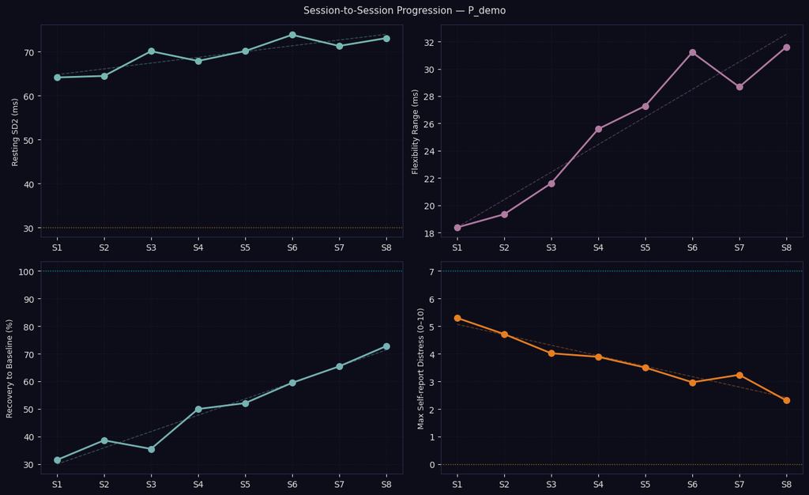

```
Trend lines (dashed) show the adaptation direction.
↑ SD2 baseline, ↑ Flexibility, ↑ Recovery, ↓ Distress = therapeutic progress confirmed.
```

```python
# Multi-session progression tracker
# ─── Replace with real session data as sessions accumulate ────────────────────

np.random.seed(5)
n_sessions = 8

# Synthetic progression: baseline SD2 rises, range widens, recovery improves
session_dates = [f'S{i+1}' for i in range(n_sessions)]
base_sd2      = BASELINE['sd2'] + np.array([0,1.5,3,4.8,6.5,8,9.2,10.5]) + np.random.normal(0, 1.5, n_sessions)
flex_range    = np.array([18,20,24,26,28,30,32,33]) + np.random.normal(0, 2, n_sessions)
recovery_pct  = np.array([28,33,40,48,55,62,68,74]) + np.random.normal(0, 3, n_sessions)
distress_max  = np.array([5,4.5,4,4,3.5,3,3,2.5]) + np.random.normal(0, 0.3, n_sessions)

fig, axes = plt.subplots(2, 2, figsize=(13, 8))
fig.patch.set_facecolor(BG)

panels = [
    (axes[0,0], base_sd2, 'Resting SD2 (ms)', ACC, None, (30, None)),
    (axes[0,1], flex_range, 'Flexibility Range (ms)', '#b07aa1', None, (None, None)),
    (axes[1,0], recovery_pct, 'Recovery to Baseline (%)', '#76b2b2', None, (None, 100)),
    (axes[1,1], distress_max, 'Max Self-report Distress (0–10)', '#e67e22', None, (0, 7)),
]

for ax, data, ylabel, colour, target, (ylo, yhi) in panels:
    ax.set_facecolor(BG)
    ax.plot(session_dates, data, 'o-', color=colour, linewidth=2, markersize=7)
    z = np.polyfit(range(n_sessions), data, 1)
    p = np.poly1d(z)
    ax.plot(session_dates, p(range(n_sessions)), '--', color=colour, alpha=0.4, linewidth=1)
    if ylo is not None: ax.axhline(ylo, color='orange', linestyle=':', alpha=0.6, linewidth=1)
    if yhi is not None: ax.axhline(yhi, color='cyan', linestyle=':', alpha=0.6, linewidth=1)
    ax.set_ylabel(ylabel, color=FG, fontsize=9)
    ax.tick_params(colors=FG)
    for sp in ax.spines.values(): sp.set_edgecolor('#2a2a4a')
    ax.grid(color='#1e1e3a', linestyle='--', alpha=0.4)

plt.suptitle(f'Session-to-Session Progression — {PATIENT_ID}', color=FG, fontsize=11)
plt.tight_layout()
plt.savefig('../outputs/figures/doe_session_progression.png', dpi=130, bbox_inches='tight', facecolor=BG)
plt.show()
print('Trend lines (dashed) show the adaptation direction.')
print('↑ SD2 baseline, ↑ Flexibility, ↑ Recovery, ↓ Distress = therapeutic progress confirmed.')
```

## Model Evolution — When to Go Deeper

Start with the simplest model that fits. Only upgrade when the current model fails a quality gate.

| Gate | Criterion | If failing → upgrade to |
| --- | --- | --- |
| Phase 1 linear | R² < 0.5 | Check execution; if data clean, skip to Phase 2 earlier |
| Phase 2 quadratic | R² < 0.7 | Add more CCD points; or add 3rd factor |
| GP adaptive | σ_max > 10 ms consistently | Targeted dense sampling in high-uncertainty region |
| Multi-session | Model coefficients shifting > 20% per session | Re-run Phase 1 (patient has adapted — new baseline) |

**You do NOT need to go to a complex model if simpler ones explain the data.** A well-validated linear model is more trustworthy for clinical decisions than an over-fit neural network.

> 🏁 **Exit criterion:** When the patient achieves autonomic flexibility range > 30 ms *and* recovery > 70% for 3 consecutive sessions, the model can be used in "prescription mode" — delivering the optimal protocol from Phase 3 with only monitoring, no further experimentation required.

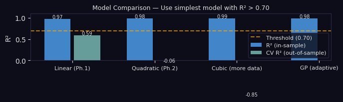

```
Key insight: if in-sample R² >> CV R², the model is overfitting.
In that case: collect more data, or step back to a simpler model.
```

```python
# Compare model quality as data accumulates across phases
# Illustrates the principle: use simplest model with adequate fit

from sklearn.preprocessing import PolynomialFeatures
from sklearn.linear_model import LinearRegression
from sklearn.model_selection import cross_val_score

X2 = ccd_coded
y2 = y2_sd2

results = {}
for deg, label in [(1, 'Linear (Ph.1)'), (2, 'Quadratic (Ph.2)'), (3, 'Cubic (more data)')]:
    pf    = PolynomialFeatures(degree=deg, include_bias=True)
    Xp    = pf.fit_transform(X2)
    if Xp.shape[1] >= len(y2):
        results[label] = {'R²': float('nan'), 'CV R²': float('nan'), 'n_params': Xp.shape[1]}
        continue
    lm    = LinearRegression(fit_intercept=False).fit(Xp, y2)
    r2    = r2_score(y2, lm.predict(Xp))
    cv_r2 = cross_val_score(LinearRegression(fit_intercept=False), Xp, y2, cv=min(5, len(y2)-1), scoring='r2').mean()
    results[label] = {'R²': r2, 'CV R²': cv_r2, 'n_params': Xp.shape[1]}

# GP
gp_pred = gp.predict(X2, return_std=False)
gp_r2      = r2_score(y2, gp_pred)
results['GP (adaptive)'] = {'R²': gp_r2, 'CV R²': float('nan'), 'n_params': 'kernel'}

fig, ax = plt.subplots(figsize=(7, 3.5))
fig.patch.set_facecolor(BG); ax.set_facecolor(BG)
labels_m = list(results.keys())
r2_vals  = [results[k]['R²'] for k in labels_m]
cv_vals  = [results[k]['CV R²'] for k in labels_m]
x_pos    = np.arange(len(labels_m))
bars1 = ax.bar(x_pos - 0.18, r2_vals, width=0.32, label='R² (in-sample)', color='#4c9be8', alpha=0.85)
bars2 = ax.bar(x_pos + 0.18, cv_vals, width=0.32, label='CV R² (out-of-sample)', color=ACC, alpha=0.85)
ax.axhline(0.7, color='orange', linestyle='--', alpha=0.7, label='Threshold (0.70)')
ax.set_xticks(x_pos); ax.set_xticklabels(labels_m, color=FG, fontsize=8)
ax.set_ylabel('R²', color=FG); ax.set_ylim(0, 1.1)
ax.tick_params(colors=FG)
for sp in ax.spines.values(): sp.set_edgecolor('#2a2a4a')
ax.legend(facecolor=BG, edgecolor='#2a2a4a', labelcolor=FG, fontsize=8)
ax.set_title('Model Comparison — Use simplest model with R² > 0.70', color=FG, fontsize=9)
for bar in bars1 + bars2:
    h = bar.get_height()
    if not np.isnan(h):
        ax.text(bar.get_x() + bar.get_width()/2, h + 0.015, f'{h:.2f}',
                ha='center', color=FG, fontsize=7)
plt.tight_layout()
plt.savefig('../outputs/figures/doe_model_comparison.png', dpi=130, bbox_inches='tight', facecolor=BG)
plt.show()
print('\nKey insight: if in-sample R² >> CV R², the model is overfitting.')
print('In that case: collect more data, or step back to a simpler model.')
```